# We8There Text Example

Mladen Kolar (mkolar@chicagobooth.edu)

Let us a look at variable selection with logistic regression.

```r
library(textir)    # dataset is in this package
library(glmnet)
data(we8there)
```

We have 6166 reviews, from the now-defunct travel website `we8there.com`. On average the length a review is 90 words.

Reviews contain both text and a multidimensional rating on overall experience, atmosphere, food, service, and value. Each aspect is rated on a five-point scale, with 1 indicating terrible and 5 indicating excellent.

```r
head(we8thereRatings)
```

```
##    Food Service Value Atmosphere Overall
## 1     5       5     5          5       5
## 2     5       5     5          5       5
## 5     5       5     4          4       5
## 11    5       5     5          5       5
## 12    5       5     5          4       5
## 13    5       5     5          5       5
```

Here are the words from some of the reviews

```r
we8thereCounts[1, we8thereCounts[1, ]!=0]
```

```
##  even though larg portion  mouth water     red sauc    babi back     back rib chocol mouss
##            1            1            1            1            1            1            1
## veri satisfi
##            1
```

and corresponding ratings

```r
we8thereRatings[1, ]
```

```
##   Food Service Value Atmosphere Overall
## 1    5       5     5          5       5
```

```r
we8thereCounts[50, we8thereCounts[50, ]!=0]
```

```
##    food great     ice cream    french fri     went back  buffalo wing american food
##             1             1             1             1             1             1
```

```r
we8thereRatings[50, ]
```

```
##    Food Service Value Atmosphere Overall
## 75    5       5     5          5       5
```

```r
we8thereCounts[5200, we8thereCounts[5200, ]!=0]
```

```
##     minut after veri disappoint      blue chees   husband order      goat chees     order salad
##               1               1               1               1               4               1
##  iceberg lettuc     salad entre        veri few
##               1               1               1
```

```r
we8thereRatings[5200, ]
```

```
##      Food Service Value Atmosphere Overall
## 1803    2       3     3          3       2
```

```r
we8thereCounts[5900, we8thereCounts[5900, ]!=0]
```

```
## food servic   came over servic good dinner menu   menu veri  kid friend  too expens  veri limit
##           1           1           1           1           1           1           1           1
```

```r
we8thereRatings[5900, ]
```

```
##      Food Service Value Atmosphere Overall
## 3556    3       2     1          3       1
```

```r
we8thereCounts[6100, we8thereCounts[6100, ]!=0]
```

```
## never return     just few     one side     tri make       go box  order wrong  place clean
##            1            1            1            1            1            1            1
##   order just     seat one   side build
##            1            1            1
```

```r
we8thereRatings[6100, ]
```

```
##      Food Service Value Atmosphere Overall
## 5563    2       1     3          1       1
```

We are going predict if the `Overall` rating is larger than 3 or not. Let us transform `Overall` rating into {0, 1}.

```r
y = ifelse(we8thereRatings$Overall>3, 1, 0)
y = as.factor(y)
```

Let us fit a lasso logistic regression. Remember that the parameter `alpha` is used to tell the function whether to use the lasso or ridge penalty.

```r
set.seed(1)
lasso.fit = cv.glmnet(x = we8thereCounts, y = y,
                    family = "binomial",
                    alpha = 1,       # lasso - 1, ridge - 0
                    nfold = 5
)
lasso.fit
```

```
##
## Call:  cv.glmnet(x = we8thereCounts, y = y, nfolds = 5, family = "binomial",      alpha = 1)
##
## Measure: Binomial Deviance
##
##      Lambda Index Measure      SE Nonzero
## min 0.00375    32   0.782 0.00973     945
## 1se 0.00496    29   0.789 0.00934     786
```

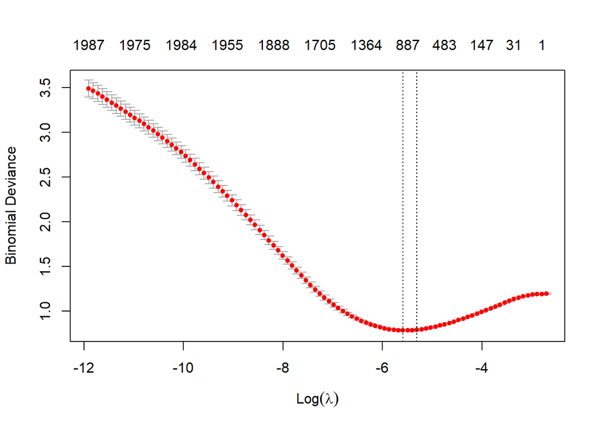

```r
plot(lasso.fit)
```

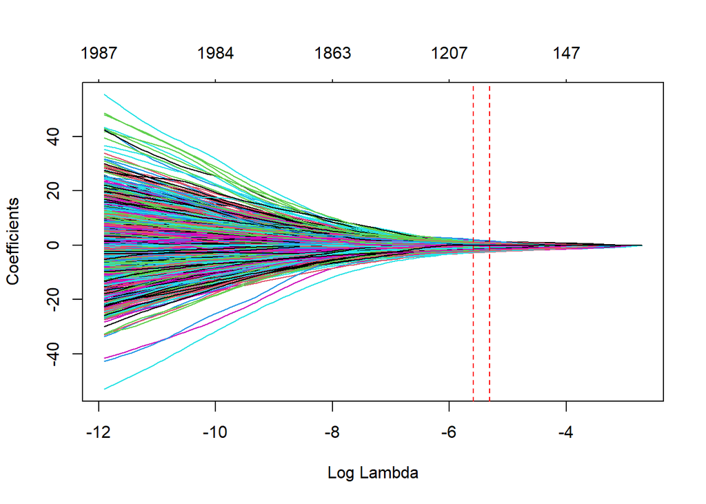

```r
plot(lasso.fit$glmnet.fit, xvar = "lambda")
abline(v = log(lasso.fit$lambda.min), lty=2, col="red")
abline(v = log(lasso.fit$lambda.1se), lty=2, col="red")
```

Here `lasso.fit$glmnet.fit` object is obtained by fitting all of data.

```r
lasso.1se.coef = coef(lasso.fit$glmnet.fit, s=lasso.fit$lambda.1se)
```

What are positive words?

```r
oo = order( lasso.1se.coef, decreasing = TRUE )
dimnames(lasso.1se.coef)[[1]][oo[1:10]]
```

```
##  [1] "between two"    "can wait"       "beef sandwich"  "friend help"    "best meal"
##  [6] "high recommend" "cannot wait"    "melt mouth"     "food delici"    "portion huge"
```

```r
lasso.1se.coef[oo[1:10]]
```

```
##  [1] 1.62358 1.38601 1.36721 1.34140 1.29763 1.28638 1.17198 1.15027 1.12885 1.10329
```

What are negative words?

```r
dimnames(lasso.1se.coef)[[1]][tail(oo,10)]
```

```
##  [1] "never go"       "gone down"      "servic terribl" "food terribl"   "never return"
##  [6] "stay away"      "far better"     "mediocr best"   "veri rude"      "extrem rude"
```

```r
lasso.1se.coef[tail(oo,10)]
```

```
##  [1] -1.89980 -2.02595 -2.03537 -2.04434 -2.08783 -2.09716 -2.26786 -2.27763 -2.32228 -2.52403
```

Let us now fit a logistic regression with the ridge penalty.

```r
ridge.fit = cv.glmnet(x = we8thereCounts, y = y,
                          family = "binomial",
                          alpha = 0,                        # lasso - 1, ridge - 0
                          nfold = 5
)
ridge.fit
```

```
##
## Call:  cv.glmnet(x = we8thereCounts, y = y, nfolds = 5, family = "binomial",      alpha = 0)
##
## Measure: Binomial Deviance
##
##     Lambda Index Measure     SE Nonzero
## min 0.0997    71   0.772 0.0205    2640
## 1se 0.2098    63   0.791 0.0168    2640
```

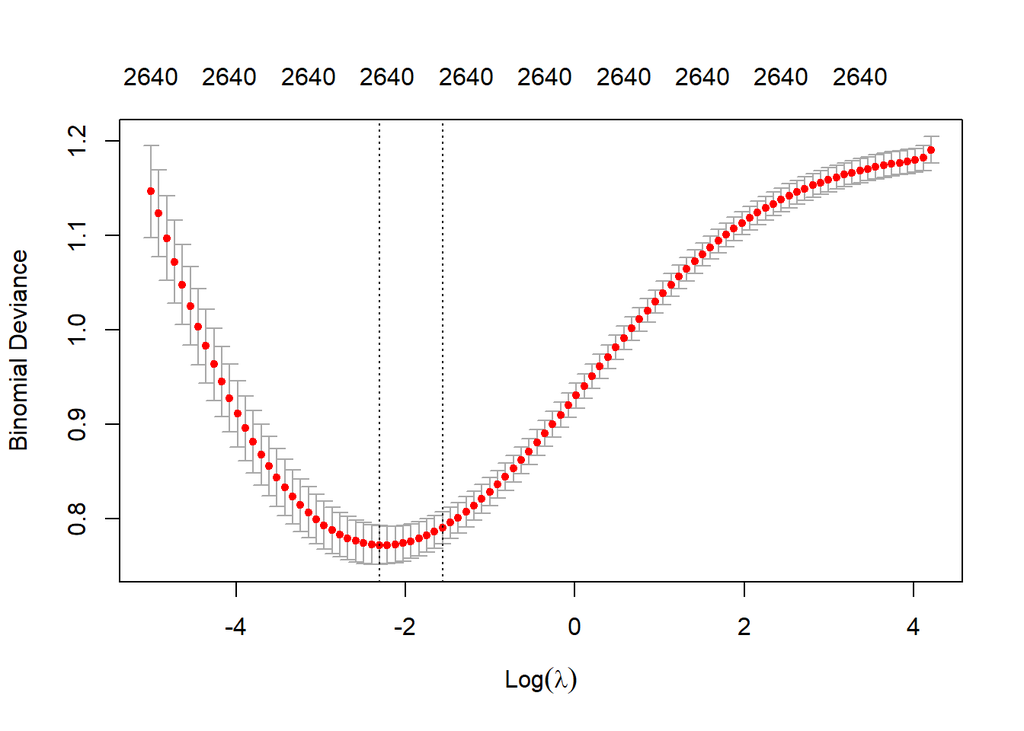

```r
plot(ridge.fit)
```

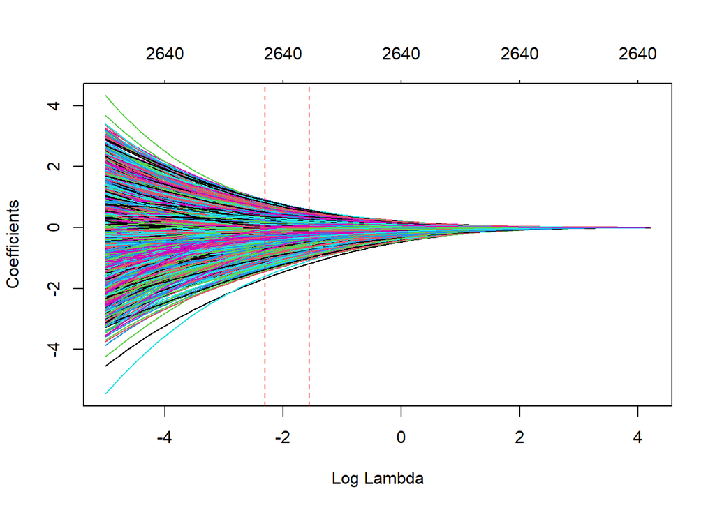

```r
plot(ridge.fit$glmnet.fit, xvar = "lambda")
abline(v = log(ridge.fit$lambda.min), lty=2, col="red")
abline(v = log(ridge.fit$lambda.1se), lty=2, col="red")
```

```r
ridge.1se.coef = coef(ridge.fit$glmnet.fit, s=ridge.fit$lambda.1se)
```

What are positive words?

```r
oo = order( ridge.1se.coef, decreasing = TRUE )
dimnames(ridge.1se.coef)[[1]][oo[2:11]]
```

```
##  [1] "veri uniqu"     "coconut shrimp" "servic attent"  "look out"       "everyth menu"
##  [6] "year food"      "friend help"    "well food"      "half shell"     "absolut best"
```

```r
ridge.1se.coef[oo[2:11]]
```

```
##  [1] 0.586054 0.584909 0.584815 0.581012 0.575701 0.574253 0.571799 0.568777 0.568641 0.562635
```

What are negative words?

```r
dimnames(ridge.1se.coef)[[1]][tail(oo,10)]
```

```
##  [1] "complain manag" "mediocr food"   "food averag"    "food okay"      "veri rude"
##  [6] "veri slow"      "mediocr best"   "gone down"      "far better"     "extrem rude"
```

```r
ridge.1se.coef[tail(oo,10)]
```

```
##  [1] -0.942494 -0.945921 -0.962658 -0.994604 -0.995403 -0.998672 -1.038664 -1.044315 -1.088993
## [10] -1.182687
```